# RRBS - BiSeq J20 Part 2 - Adapted Beta Regression

Isabel Castanho (I.S.Castanho@exeter.ac.uk)

01 July 2020

To detect the CpG sites where the DNA methylation differs between TG and WT samples we model the methylation within a beta regression./

```r
numCores <- detectCores()
numCores
```

```
## [1] 16
```

### 3. Model and test group effect

```r
# colData(predictedMeth)$Age_months <- as.numeric(as.character(colData(predictedMeth)$Age_months))
# # Age had been saved as factor so we changed to numeric before running the beta regression
#
# betaResults <- betaRegressionAdapted(formula = ~Genotype + Age_months + Genotype*Age_months,
#                                      formulaNull = ~Genotype + Age_months,
#                                      link = "probit",
#                                      object = predictedMeth,
#                                      type = "BR",
#                                      mc.cores = 16)
# # betaResults is a data.frame containing model and test information for each CpG site
# # By setting type = "BR" the maximum likelihood with bias reduction is called
#
# save(betaResults, file = "/gpfs/ts0/projects/Research_Project-191406/isabel/RRBS_new/biseqBetaResults_J20.RData")
```

Head results

```r
head(betaResults)
```

```
##      chr     pos p.val.Genotype meth.group1.WT meth.group2.TG
## 1.1 chr9 3004591     0.60863166      0.9626160      0.9786789
## 2.1 chr9 3004609     0.64455622      0.9636379      0.9781213
## 3.1 chr9 3004785     0.04691984      0.9383302      0.9856018
## 4.1 chr9 3004797     0.06641235      0.9409746      0.9845387
## 5.1 chr9 3004825     0.11748848      0.9461671      0.9830018
## 6.1 chr9 3080684     0.78801404      0.8488583      0.8258162
##     meth.diff.Genotype estimate.Genotype std.error.Genotype pseudo.R.sqrt
## 1.1        -0.01606290        0.24531277          0.4791006    0.04604997
## 2.1        -0.01448338        0.22184930          0.4808825    0.05097126
## 3.1        -0.04727165        0.64535688          0.3247858    0.05299242
## 4.1        -0.04356408        0.59505887          0.3241714    0.04837402
## 5.1        -0.03683476        0.51134155          0.3266517    0.03925779
## 6.1         0.02304206       -0.09378862          0.3487987    0.01159559
##      p.val.Age estimate.Age std.error.Age p.val.Interaction
## 1.1 0.73227404  -0.01238481    0.03620209        0.42214688
## 2.1 0.68991237  -0.01448131    0.03629638        0.43697203
## 3.1 0.09110700   0.04232000    0.02504754        0.01874391
## 4.1 0.09804869   0.04140384    0.02502668        0.02809760
## 5.1 0.12314042   0.03887366    0.02521439        0.05742234
## 6.1 0.43564184  -0.02053021    0.02633518        0.71108155
##     estimate.Interaction std.error.Interaction p.val.modelLRT cluster.id
## 1.1          -0.04171369            0.05196658     0.44941549     chr9_1
## 2.1          -0.04055776            0.05217663     0.46632431     chr9_1
## 3.1          -0.08223003            0.03498279     0.01669777     chr9_1
## 4.1          -0.07672361            0.03493915     0.02540004     chr9_1
## 5.1          -0.06694120            0.03523069     0.05429447     chr9_1
## 6.1           0.01386107            0.03742151     0.82948212     chr9_2
```

Summary results

```r
summary(betaResults)
```

```
##       chr               pos            p.val.Genotype   meth.group1.WT
##  chr11  : 144444   Min.   :      134   Min.   :0.0000   Min.   :0.0000
##  chr2   : 140739   1st Qu.: 40896056   1st Qu.:0.1885   1st Qu.:0.0096
##  chr4   : 133953   Median : 77714242   Median :0.4569   Median :0.0245
##  chr5   : 132621   Mean   : 78560670   Mean   :0.4650   Mean   :0.2357
##  chr7   : 118305   3rd Qu.:113636036   3rd Qu.:0.7308   3rd Qu.:0.3808
##  chr8   : 105987   Max.   :195357106   Max.   :1.0000   Max.   :0.9997
##  (Other):1033141                       NA's   :1670     NA's   :1670
##  meth.group2.TG   meth.diff.Genotype estimate.Genotype std.error.Genotype
##  Min.   :0.0002   Min.   :-0.9864    Min.   :-4.2715   Min.   :0.0266
##  1st Qu.:0.0112   1st Qu.:-0.0191    1st Qu.:-0.2194   1st Qu.:0.3083
##  Median :0.0286   Median :-0.0020    Median : 0.0547   Median :0.3610
##  Mean   :0.2476   Mean   :-0.0118    Mean   : 0.0636   Mean   :0.4163
##  3rd Qu.:0.4577   3rd Qu.: 0.0103    3rd Qu.: 0.3376   3rd Qu.:0.4764
##  Max.   :0.9994   Max.   : 0.9389    Max.   : 4.9359   Max.   :1.6491
##  NA's   :1670     NA's   :1670       NA's   :1670      NA's   :1670
##  pseudo.R.sqrt      p.val.Age       estimate.Age     std.error.Age
##  Min.   :0.0000   Min.   :0.0000   Min.   :-0.3423   Min.   :0.0020
##  1st Qu.:0.0212   1st Qu.:0.1857   1st Qu.:-0.0163   1st Qu.:0.0234
##  Median :0.0411   Median :0.4558   Median : 0.0043   Median :0.0274
##  Mean   :0.0507   Mean   :0.4638   Mean   : 0.0056   Mean   :0.0316
##  3rd Qu.:0.0698   3rd Qu.:0.7307   3rd Qu.: 0.0262   3rd Qu.:0.0362
##  Max.   :0.4784   Max.   :1.0000   Max.   : 0.4175   Max.   :0.1449
##  NA's   :1670     NA's   :1670     NA's   :1670      NA's   :1670
##  p.val.Interaction estimate.Interaction std.error.Interaction p.val.modelLRT
##  Min.   :0.0000    Min.   :-0.5243      Min.   :0.0029        Min.   :0.0000
##  1st Qu.:0.1892    1st Qu.:-0.0363      1st Qu.:0.0332        1st Qu.:0.1935
##  Median :0.4573    Median :-0.0061      Median :0.0388        Median :0.4992
##  Mean   :0.4653    Mean   :-0.0066      Mean   :0.0448        Mean   :0.4706
##  3rd Qu.:0.7310    3rd Qu.: 0.0235      3rd Qu.:0.0513        3rd Qu.:0.7399
##  Max.   :1.0000    Max.   : 0.4898      Max.   :0.1689        Max.   :0.9997
##  NA's   :1670      NA's   :1670         NA's   :1670          NA's   :1671
##   cluster.id
##  Length:1809190
##  Class :character
##  Mode  :character
##
##
##
##
```

### 4.1. Test CpG clusters for differential methylation

The aim is to detect CpG clusters containing at least one differentially methylated location. To do so the P values p from the Wald tests are transformed to Z scores: z= Φ−1(1−p), which are normally distributed under Null hypothesis (no group effect). As cluster test statistic a standardized Z score average is used. To estimate the standard deviation of the Z scores we have to estimate the correlation and hence the variogram of methylation between two CpG sites within a cluster. The estimation of the standard deviation requires that the distribution of the Z scores follows a standard normal distribution. However, if methylation in both groups differs for many CpG sites the density distribution of P values shows a peak near 0.  
To ensure that the P values are roughly uniformly distributed to get a variance of the Z scores that is Gaussian with variance 1 we recommend to estimate the variogram (and hence the correlation of Z scores) under the null hypothesis. To do so we model the beta regression again for resampled data:

```r
# # Both resampled groups should have the same number of
# # cases and control samples:
# # Take bottom 16 rows of the ColData predictedMeth
# predictedMethNull <- predictedMeth[,46:61]
# # Age and Genotype selected are random to not group based on genotype or age - we selected 16 for 2 genotype, 4 time points and repeated twice to increase randomness
# colData(predictedMethNull)$group.null <- rep(c(1,2), each = 8)
# print(colData(predictedMethNull))
# # To shorten the run time, please set mc.cores, if possible!
# betaResultsNull <- betaRegression(formula = ~group.null,
#                                         link = "probit",
#                                         object = predictedMethNull,
#                                         type="BR",
#                                         mc.cores = 16)
#
# vario <- makeVariogram(betaResultsNull)
#
# save(betaResultsNull, vario, predictedMethNull,
#       file = "/gpfs/ts0/projects/Research_Project-191406/isabel/RRBS_new/biseqBetaResultsNull_J20.RData")
```

```r
# Load the previous chunk betaResultsNull rdat object. Also print the samples used to generate the betaResultsNull
load("/gpfs/ts0/projects/Research_Project-191406/isabel/RRBS_new/biseqBetaResultsNull_J20.RData")
print(colData(predictedMethNull))
```

```
## DataFrame with 16 rows and 8 columns
##      Mouse_ID Genotype Age_months    Group_ID Histology_no        HIP       ECX
##     <integer> <factor>  <numeric> <character>  <character>  <numeric> <numeric>
## G21         7       WT          6   J20_WT_6m       16/147 0.00722972     9e-04
## G22        17       TG          6   J20_TG_6m       16/157    1.65287     8e-04
## G23        27       WT          8   J20_WT_8m       16/167 0.00124875     7e-04
## G24        37       TG          8   J20_TG_8m       16/177    2.00278    0.0128
## H17        68       WT         12  J20_WT_12m       16/208 0.00421634         0
## ...       ...      ...        ...         ...          ...        ...       ...
## J17        30       WT          8   J20_WT_8m       16/170          0    0.0019
## J19        50       WT         10  J20_WT_10m       16/190 0.00257392         0
## J20        60       TG         10  J20_TG_10m       16/200     5.1205    0.0762
## J21        70       WT         12  J20_WT_12m       16/210   3.45e-05         0
## J22        80       TG         12  J20_TG_12m       16/220    13.9409    0.3517
##     group.null
##      <numeric>
## G21          1
## G22          1
## G23          1
## G24          1
## H17          1
## ...        ...
## J17          2
## J19          2
## J20          2
## J21          2
## J22          2
```

We estimate the variogram for the Z scores obtained for the resampled data.  
Based on the variogram plot we evaluate the sill (usually near 1) of the variogram and smooth the curve:

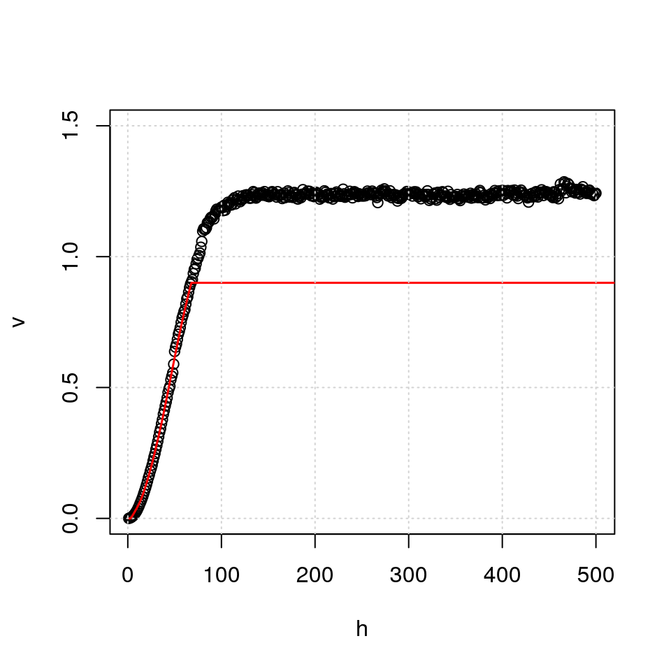

Figure 5: Estimated variogram together with the smoothed curve

```r
plot(vario$variogram$v, ylim = c(0, 1.5))
vario.sm <- smoothVariogram(vario, sill = 0.9) # The vario.sm object is a list of two: "variogram" "pValsList"
lines(vario.sm$variogram[,c("h", "v.sm")],col = "red", lwd = 1.5)
grid()
```

```r
# Save all ojects from betaResultsNull
resave(betaResultsNull, vario, vario.sm, predictedMethNull,
     file = "/gpfs/ts0/projects/Research_Project-191406/isabel/RRBS_new/biseqBetaResultsNull_J20.RData")
```

```r
head(vario.sm$pValsList[[1]])
```

```
##           chr     pos      p.val meth.group1 meth.group2   meth.diff   estimate
## 7.74463  chr1 3020795 0.50315857   0.5667419   0.5055149  0.06122700 -0.1542610
## 8.74463  chr1 3020815 0.01704079   0.9662381   0.8571682  0.10906989 -0.7604890
## 9.74463  chr1 3020843 0.11026037   0.9463720   0.8712879  0.07508416 -0.4781503
## 10.74463 chr1 3020877 0.06264251   0.6146327   0.7827643 -0.16813155  0.4901488
## 11.74463 chr1 3020891 0.03708949   0.4724918   0.7070266 -0.23453478  0.6137265
## 12.74463 chr1 3020946 0.03123281   0.3760604   0.6396990 -0.26363862  0.6734986
##          std.error pseudo.R.sqrt cluster.id      z.score pos.new
## 7.74463  0.2304026    0.04494165     chr1_1 -0.007917449       1
## 8.74463  0.3187528    0.15120983     chr1_1  2.119105199      21
## 9.74463  0.2994008    0.06088925     chr1_1  1.225144610      49
## 10.74463 0.2632773    0.14749485     chr1_1  1.532962773      83
## 11.74463 0.2943846    0.20055993     chr1_1  1.785507826      97
## 12.74463 0.3126598    0.20809756     chr1_1  1.862976124     152
```

```r
# Subset the betaresults for: Genotype,Age,Genotype*Age interaction
load("/gpfs/ts0/projects/Research_Project-191406/isabel/RRBS_new/biseqBetaResults_J20.RData")
# Change colnames of the betaresults dataframe

# Genotype
betaResultsGenotype <- betaResults[,c(1:9,17)]
colnames(betaResultsGenotype) <- colnames(betaResultsNull)

# Interaction (meth groups 1&2 and diff are WT vs TG)
betaResultsInteraction <- betaResults[,c(1:2,13,4:6,14:15,9,17)]
colnames(betaResultsInteraction) <- colnames(betaResultsNull)
```

## Genotype

```r
# We replace the pValsList object (which consists of the test results of the resampled data) by the test results of interest (for group effect)
## auxiliary object to get the pValsList for the test
## results of interest

vario.aux <- makeVariogram(betaResultsGenotype, make.variogram=FALSE)
vario.sm$pValsList <- vario.aux$pValsList
head(vario.sm$pValsList[[1]])
```

```
##           chr     pos     p.val meth.group1 meth.group2   meth.diff   estimate
## 7.74463  chr1 3020795 0.7938161   0.3678977   0.4028990 -0.03500131 0.09157609
## 8.74463  chr1 3020815 0.7287501   0.7147219   0.7975378 -0.08281596 0.26562640
## 9.74463  chr1 3020843 0.8234726   0.7213014   0.7744700 -0.05316867 0.16693731
## 10.74463 chr1 3020877 0.7488122   0.5441615   0.6364325 -0.09227107 0.23801581
## 11.74463 chr1 3020891 0.6779632   0.4452792   0.5730829 -0.12780374 0.32182627
## 12.74463 chr1 3020946 0.3054216   0.3614948   0.6819833 -0.32048843 0.82771791
##          std.error pseudo.R.sqrt cluster.id    z.score pos.new
## 7.74463  0.3503850    0.07341854     chr1_1 -0.8197339       1
## 8.74463  0.7659606    0.01234221     chr1_1 -0.6090373      21
## 9.74463  0.7483266    0.01946140     chr1_1 -0.9286803      49
## 10.74463 0.7433210    0.02422882     chr1_1 -0.6707566      83
## 11.74463 0.7750290    0.03206332     chr1_1 -0.4620107      97
## 12.74463 0.8076272    0.02040443     chr1_1  0.5088703     152
```

vario.sm contains the smoothed variogram under the Null hypothesis together with the P values (and Z scores) from the Wald test, that the group has no effect on methylation. The correlation of the Z scores between two locations in a cluster can now be estimated:

```r
# Correlaton is based on z-scores
locCor <- estLocCor(vario.sm)
```

We test each CpG cluster for the presence of at least one differentially methylated location at q what can be interpreted as the size-weighted FDR on clusters:

```r
clusters.rej <- testClusters(locCor, FDR.cluster = 0.10)
```

```
## 254 CpG clusters rejected.
```

```r
clusters.rej$clusters.reject
```

```
## GRanges object with 254 ranges and 2 metadata columns:
##         seqnames              ranges strand |           X              p.value
##            <Rle>           <IRanges>  <Rle> | <character>            <numeric>
##     [1]     chr1   68469098-68469352      * |   chr1_1350 9.98638728362256e-05
##     [2]     chr1   74601175-74601436      * |   chr1_1552 6.13969722430552e-05
##     [3]     chr1   89264056-89264487      * |   chr1_2051 5.31072795860732e-05
##     [4]     chr1   89724608-89724715      * |   chr1_2090 7.84796024817513e-05
##     [5]     chr1   89921447-89922111      * |   chr1_2116 0.000189224003845245
##     ...      ...                 ...    ... .         ...                  ...
##   [250]     chrX 164428798-164428852      * |   chrX_2144 6.45000523729067e-05
##   [251]     chrX 169926626-169927507      * |   chrX_2216 9.42938109316227e-06
##   [252]     chrX   14294862-14294949      * |    chrX_271 3.96845044392524e-06
##   [253]     chrX   39069609-39069655      * |    chrX_510 7.31268562526033e-06
##   [254]     chrY   90741078-90744840      * |      chrY_7 3.91314711563062e-05
##   -------
##   seqinfo: 22 sequences from an unspecified genome; no seqlengths
```

### 4.2. Trim significant CpG clusters

We then trim the rejected CpG clusters that is to remove the not dierentially methylated CpG sites at q1 what can be interpreted as the location-wise FDR

```r
clusters.trimmed <- trimClusters(clusters.rej, FDR.loc = 0.05)
head(clusters.trimmed)
```

```
##                     chr       pos        p.val meth.group1 meth.group2
## chr2_2595.1.27257  chr2  84519433 1.877344e-08 0.005107590   0.8995760
## chr2_2595.2.27257  chr2  84519438 1.716147e-08 0.005081526   0.8991125
## chr2_2595.3.27257  chr2  84519439 1.754047e-08 0.005112975   0.8994079
## chr2_2595.4.27257  chr2  84519464 3.362349e-08 0.006008277   0.8974617
## chr6_3628.1.102766 chr6 131669771 1.353123e-08 0.998755812   0.8146041
## chr6_3628.2.102766 chr6 131669779 1.399506e-09 0.998777154   0.7798841
##                     meth.diff  estimate std.error pseudo.R.sqrt cluster.id
## chr2_2595.1.27257  -0.8944684  3.847598 0.6842680     0.2233974  chr2_2595
## chr2_2595.2.27257  -0.8940310  3.846743 0.6822373     0.2239579  chr2_2595
## chr2_2595.3.27257  -0.8942950  3.846279 0.6826108     0.2236297  chr2_2595
## chr2_2595.4.27257  -0.8914534  3.778878 0.6844009     0.2148018  chr2_2595
## chr6_3628.1.102766  0.1841517 -2.129760 0.3750094     0.2411614  chr6_3628
## chr6_3628.2.102766  0.2188930 -2.258179 0.3729115     0.2434912  chr6_3628
##                     z.score pos.new         p.li
## chr2_2595.1.27257  5.502018     546 5.956033e-05
## chr2_2595.2.27257  5.517821     551 5.898770e-05
## chr2_2595.3.27257  5.513980     552 6.051455e-05
## chr2_2595.4.27257  5.398376     577 7.018188e-05
## chr6_3628.1.102766 5.559451       1 4.320802e-05
## chr6_3628.2.102766 5.942971       9 7.321674e-06
```

```r
# clusters.trimmed is a data.frame object containing all differentially methylated CpG sites. The p.li column contains the P values estimated in the cluster trimming step
```

### 5. Defnition of DMR boundaries

We can now define the boundaries of DMRs as rejected CpG sites within which rejected CpG sites solely are located.  
Within the DMRs the distance between neighbored rejected CpG sites should not exceed max.dist base pairs (usually the same as for max.dist in clusterSites), otherwise, the DMR is splitted.  
DMRs are also splitted if the methylation diference switches from positive to negative, or vice versa, if diff.dir = TRUE.  
That way we ensure that within a DMR all CpG sites are hypermethylated, and hypomethylated respectively.

```r
DMRs <- findDMRs(clusters.trimmed,
                 max.dist = 500,
                 diff.dir = TRUE)
DMRs
```

```
## GRanges object with 2 ranges and 4 metadata columns:
##       seqnames              ranges strand |             median.p
##          <Rle>           <IRanges>  <Rle> |            <numeric>
##   [1]     chr2   84519433-84519464      * | 1.81569562010716e-08
##   [2]     chr6 131669771-131669779      * | 7.46536996927834e-09
##        median.meth.group1 median.meth.group2   median.meth.diff
##                 <numeric>          <numeric>          <numeric>
##   [1] 0.00511028255425392  0.899260222751222 -0.894162972694484
##   [2]   0.998766482944583  0.797244102215723   0.20152238072886
##   -------
##   seqinfo: 22 sequences from an unspecified genome; no seqlengths
```

```r
DMRsGenotype <- as.data.frame(DMRs)
write.csv(DMRsGenotype,
          file = "/gpfs/ts0/projects/Research_Project-191406/isabel/RRBS_new/DMRs/J20/DMRsGenotype.csv")

DMRsGenotype <- DMRs
save(betaResultsGenotype, DMRsGenotype,
     file = "/gpfs/ts0/projects/Research_Project-191406/isabel/RRBS_new/biseqResultsGenotype_J20.RData")
```

## Interaction

```r
# We need to reload  betaResulstNull Objects & repeat as genotype section chunks
load("/gpfs/ts0/projects/Research_Project-191406/isabel/RRBS_new/biseqBetaResults_J20.RData")
```

```r
# We replace the pValsList object (which consists of the test results of the resampled data) by the test results of interest (for group effect)
## auxiliary object to get the pValsList for the test
## results of interest

vario.aux <- makeVariogram(betaResultsInteraction, make.variogram=FALSE)
vario.sm$pValsList <- vario.aux$pValsList
head(vario.sm$pValsList[[1]])
```

```
##           chr     pos     p.val meth.group1 meth.group2   meth.diff
## 7.74463  chr1 3020795 0.9878584   0.3678977   0.4028990 -0.03500131
## 8.74463  chr1 3020815 0.5154082   0.7147219   0.7975378 -0.08281596
## 9.74463  chr1 3020843 0.5762516   0.7213014   0.7744700 -0.05316867
## 10.74463 chr1 3020877 0.8831415   0.5441615   0.6364325 -0.09227107
## 11.74463 chr1 3020891 0.8296150   0.4452792   0.5730829 -0.12780374
## 12.74463 chr1 3020946 0.2685269   0.3614948   0.6819833 -0.32048843
##               estimate  std.error pseudo.R.sqrt cluster.id     z.score pos.new
## 7.74463   0.0005637749 0.03704712    0.07341854     chr1_1 -2.25261991       1
## 8.74463  -0.0539124766 0.08288620    0.01234221     chr1_1 -0.03863229      21
## 9.74463  -0.0451198322 0.08073428    0.01946140     chr1_1 -0.19231325      49
## 10.74463 -0.0115845667 0.07881299    0.02422882     chr1_1 -1.19083831      83
## 11.74463 -0.0176692558 0.08210797    0.03206332     chr1_1 -0.95264494      97
## 12.74463 -0.0957364202 0.08652487    0.02040443     chr1_1  0.61727434     152
```

vario.sm contains the smoothed variogram under the Null hypothesis together with the P values (and Z scores) from the Wald test, that the group has no effect on methylation. The correlation of the Z scores between two locations in a cluster can now be estimated:

```r
# Correlaton is based on z-scores
locCor <- estLocCor(vario.sm)
```

We test each CpG cluster for the presence of at least one differentially methylated location at q what can be interpreted as the size-weighted FDR on clusters:

```r
clusters.rej <- testClusters(locCor, FDR.cluster = 0.10)
```

```
## 160 CpG clusters rejected.
```

```r
clusters.rej$clusters.reject
```

```
## GRanges object with 160 ranges and 2 metadata columns:
##         seqnames              ranges strand |           X              p.value
##            <Rle>           <IRanges>  <Rle> | <character>            <numeric>
##     [1]     chr1   74601175-74601436      * |   chr1_1552 0.000109236107796229
##     [2]     chr1   91032600-91032667      * |   chr1_2196 2.50746797150203e-05
##     [3]     chr1   93688198-93688690      * |   chr1_2356 1.75388152768852e-05
##     [4]     chr1   20470434-20471031      * |    chr1_261 4.07873906871359e-07
##     [5]     chr1 190402985-190403897      * |   chr1_5063 3.77287143012994e-05
##     ...      ...                 ...    ... .         ...                  ...
##   [156]     chr9 111529979-111530266      * |   chr9_4042  1.5009310739944e-05
##   [157]     chr9 121299491-121300399      * |   chr9_4616 3.27919773575047e-05
##   [158]     chrX 169926626-169927507      * |   chrX_2216 3.97300484589191e-05
##   [159]     chrX   14294862-14294949      * |    chrX_271 6.18458069678862e-06
##   [160]     chrX   39069609-39069655      * |    chrX_510 2.07188987604301e-05
##   -------
##   seqinfo: 22 sequences from an unspecified genome; no seqlengths
```

### 4.2. Trim significant CpG clusters

We then trim the rejected CpG clusters that is to remove the not dierentially methylated CpG sites at q1 what can be interpreted as the location-wise FDR

```r
clusters.trimmed <- trimClusters(clusters.rej, FDR.loc = 0.05)
head(clusters.trimmed)
```

```
##                      chr      pos        p.val meth.group1 meth.group2
## chr10_145.14.81123 chr10  8635669 1.874766e-08 0.997877354   0.8332397
## chr10_145.15.81123 chr10  8635672 1.723709e-08 0.997926612   0.8319813
## chr2_2595.1.27257   chr2 84519433 1.267004e-08 0.005107590   0.8995760
## chr2_2595.2.27257   chr2 84519438 1.124133e-08 0.005081526   0.8991125
## chr2_2595.3.27257   chr2 84519439 1.152134e-08 0.005112975   0.8994079
## chr2_2595.4.27257   chr2 84519464 2.168273e-08 0.006008277   0.8974617
##                     meth.diff   estimate  std.error pseudo.R.sqrt cluster.id
## chr10_145.14.81123  0.1646377  0.2158360 0.03838328     0.2571963  chr10_145
## chr10_145.15.81123  0.1659453  0.2169032 0.03847394     0.2610488  chr10_145
## chr2_2595.1.27257  -0.8944684 -0.4211373 0.07400765     0.2233974  chr2_2595
## chr2_2595.2.27257  -0.8940310 -0.4213807 0.07378599     0.2239579  chr2_2595
## chr2_2595.3.27257  -0.8942950 -0.4212973 0.07382553     0.2236297  chr2_2595
## chr2_2595.4.27257  -0.8914534 -0.4142253 0.07399511     0.2148018  chr2_2595
##                     z.score pos.new         p.li
## chr10_145.14.81123 5.502260     450 1.180627e-04
## chr10_145.15.81123 5.517048     453 9.356693e-05
## chr2_2595.1.27257  5.570918     546 6.236902e-05
## chr2_2595.2.27257  5.591723     551 6.062316e-05
## chr2_2595.3.27257  5.587451     552 6.236966e-05
## chr2_2595.4.27257  5.476568     577 6.821640e-05
```

```r
# clusters.trimmed is a data.frame object containing all differentially methylated CpG sites. The p.li column contains the P values estimated in the cluster trimming step
```

### 5. Defnition of DMR boundaries

We can now define the boundaries of DMRs as rejected CpG sites within which rejected CpG sites solely are located.  
Within the DMRs the distance between neighbored rejected CpG sites should not exceed max.dist base pairs (usually the same as for max.dist in clusterSites), otherwise, the DMR is splitted.  
DMRs are also splitted if the methylation diference switches from positive to negative, or vice versa, if diff.dir = TRUE.  
That way we ensure that within a DMR all CpG sites are hypermethylated, and hypomethylated respectively.

```r
DMRs <- findDMRs(clusters.trimmed,
                 max.dist = 500,
                 diff.dir = TRUE)
DMRs
```

```
## GRanges object with 3 ranges and 4 metadata columns:
##       seqnames              ranges strand |             median.p
##          <Rle>           <IRanges>  <Rle> |            <numeric>
##   [1]    chr10     8635669-8635672      * |  1.7992375809262e-08
##   [2]     chr2   84519433-84519464      * | 1.20956887632591e-08
##   [3]     chr6 131669771-131669779      * | 3.24960211035877e-09
##        median.meth.group1 median.meth.group2   median.meth.diff
##                 <numeric>          <numeric>          <numeric>
##   [1]   0.997901982792971  0.832610469906584  0.165291512886388
##   [2] 0.00511028255425392  0.899260222751222 -0.894162972694484
##   [3]   0.998766482944583  0.797244102215723   0.20152238072886
##   -------
##   seqinfo: 22 sequences from an unspecified genome; no seqlengths
```

```r
DMRsInteraction <- as.data.frame(DMRs)
write.csv(DMRsInteraction,
          file = "/gpfs/ts0/projects/Research_Project-191406/isabel/RRBS_new/DMRs/J20/DMRsInteraction.csv")

DMRsInteraction <- DMRs
save(betaResultsInteraction, DMRsInteraction,
     file = "/gpfs/ts0/projects/Research_Project-191406/isabel/RRBS_new/biseqResultsInteraction_J20.RData")
```